# Intro to ggplot

Allison Horst

January 17, 2018

We’ll be using data for National Parks visitation to practice basic data visualization using ggplot (from the National Park Service at https://irma.nps.gov/Stats/SSRSReports).

Make sure to check out the Ocean Health Index Data Science Training book at http://ohi-science.org/data-science-training/, which includes more detail, examples and resources for using ggplot in Chapter 5.

## What is ggplot?

ggplot is a graphics package specifically built to help you iteratively create customized graphs. It exists solo, or within the *tidyverse* - a collection of data wrangling, visualizing, and presenting packages that play nicely together.

## Load tidyverse (install if necessary)

If you do NOT have the tidyverse installed, you may need to install it first using **install.packages(“tidyverse”)**. When you install a package, then it exists in R’s brain but is dormant.

Once it is install, you can load the tidyverse package using **library(tidyverse)** [this actually makes the package active].

You only need to install packages once, but you need to *load* them each time.

**Note: I’ll be working in an R script for this workshop. You might also make a markdown document with notes.**

```r
library(tidyverse)
```

## Get and load the NP visitation data

Load the np_visit.csv file (sent in email, or pulled from GitHub) into RStudio. Helpers will be ready to assist you.

```r
np_visit <- read_csv("np_visit.csv")
```

## Single series scatterplot (Dinosaur National Monument visitors)

First, we’ll explore visitation at Dinosaur National Monument.

Let’s make a subset of our data that only contains information for Dinosaur (I’ll call my subset dino_nm). We’ll use this subset to create our graph.

```r
dino_nm <- np_visit %>%
  filter(park_name == "Dinosaur National Monument")
```

Take a look at that data frame (View() or just click on the blue circle with arrow next to it in the Environment tab). We’ll make a scatterplot of year (x-axis) versus visitors (y-axis).

How do we make that graph in ggplot?

To make the most basic graph, you need to tell R three things:

1. You’re using ggplot
2. What data is used to create the graph
3. What type of graph you want to create

…everything beyond that is optional customization.

So code to make the most basic scatterplot for Dinosaur NM might look something like this:

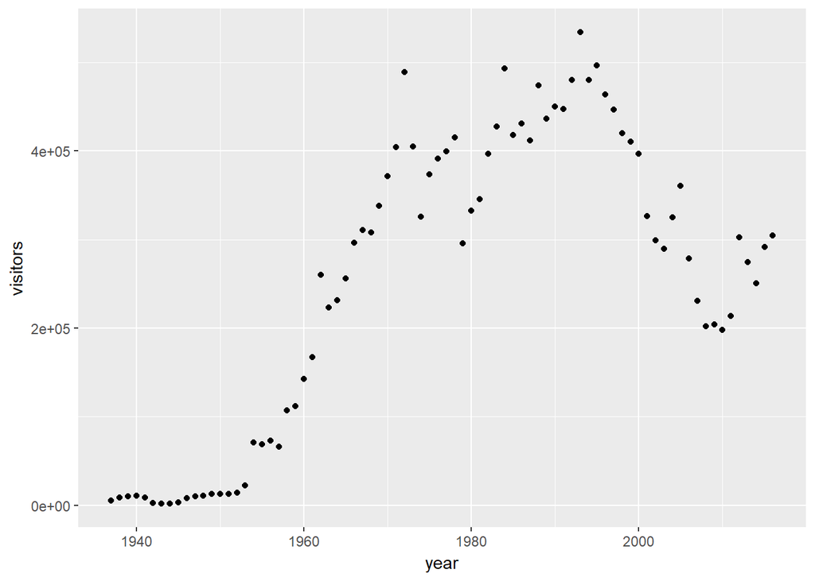

```r
ggplot(data = dino_nm, aes(x = year, y = visitors)) +
  geom_point()
```

Note that we used the aes() - aesthetics - argument here. Whenever you are referencing a variable in ggplot code, it needs to be within an aes() argument.

You’d want to customize that graph - we’ll get back to customization later on. For now, focus on the structure of the ggplot code.

What if we have more than one series we’re trying to plot?

## Multi-series graph of California National Parks visitation

Make a new subset (I’ll store as data frame ‘np_ca’) that only includes annual visitors in California National Parks, and arrange by park name (alphabetical) then year (increasing). *Note: data wrangling using dplyr and tidyr will be covered in another eco-data-sci workshop.*

```r
np_ca <- np_visit %>% # introduce pipe operator?
  filter(state == "CA" & type == "National Park") %>%
  arrange(park_name, year)
```

Go exploring a little bit. How many parks are there in California, and what are they?

```r
summary(np_ca) # Useful to see the class of each variable (column)
```

```
##     region             state               code
##  Length:789         Length:789         Length:789
##  Class :character   Class :character   Class :character
##  Mode  :character   Mode  :character   Mode  :character
##
##
##
##   park_name             type              visitors            year
##  Length:789         Length:789         Min.   :    300   Min.   :1904
##  Class :character   Class :character   1st Qu.: 111385   1st Qu.:1946
##  Mode  :character   Mode  :character   Median : 393219   Median :1973
##                                        Mean   : 607632   Mean   :1970
##                                        3rd Qu.: 797800   3rd Qu.:1995
##                                        Max.   :5028868   Max.   :2016
```

```r
unique(np_ca$park_name) # If a factor, can use 'levels' - but this is just a character
```

```
## [1] "Channel Islands National Park" "Death Valley National Park"
## [3] "Joshua Tree National Park"     "Kings Canyon National Park"
## [5] "Lassen Volcanic National Park" "Pinnacles National Park"
## [7] "Redwood National Park"         "Sequoia National Park"
## [9] "Yosemite National Park"
```

```r
length(unique(np_ca$park_name)) # To see how many there are
```

```
## [1] 9
```

Now let’s make a scatterplot graph (year v. visitors for the 9 California NPs):

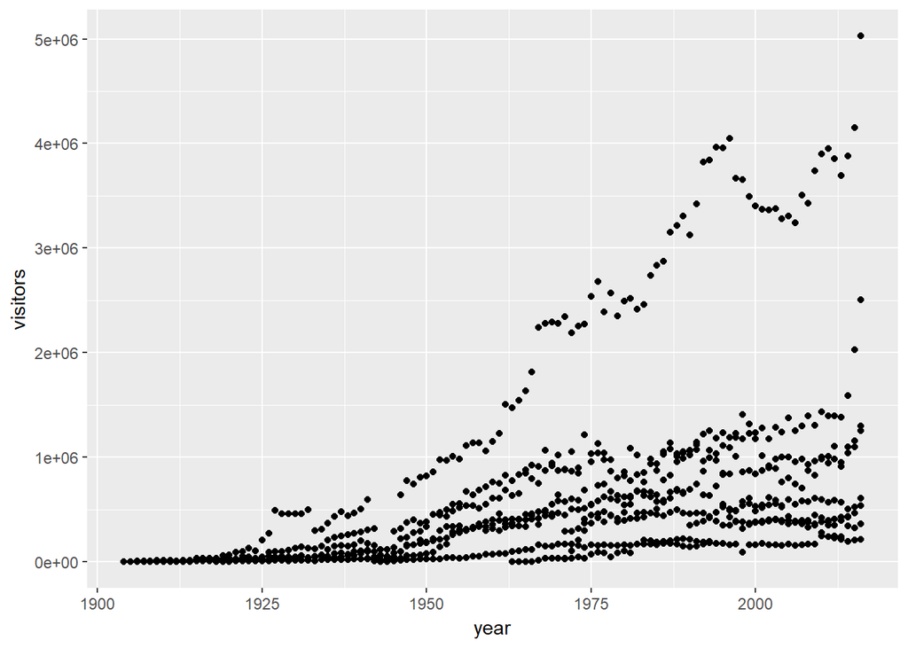

```r
ggplot(data = np_ca, aes(x = year, y = visitors)) + # There are (1) and (2)
  geom_point() # This is (3) - what type of graph do you want to create?
```

Now you have made a totally hideous and useless graph - but it DOES contain all of the correct data. We just need to figure out how to clean it up a little bit to make it useful.

How do we do that?

## Updating series characteristics by *variable*

We would like for each CA National Park series to be shown in a different color. We can do that by updating within the geom_point() layer (that’s the layer where the points are added…). Since we’re referencing a variable (park_name), we’ll need to use the aes() argument. Anything that is not variable specified can be added outside of an aes() argument.

Like this:

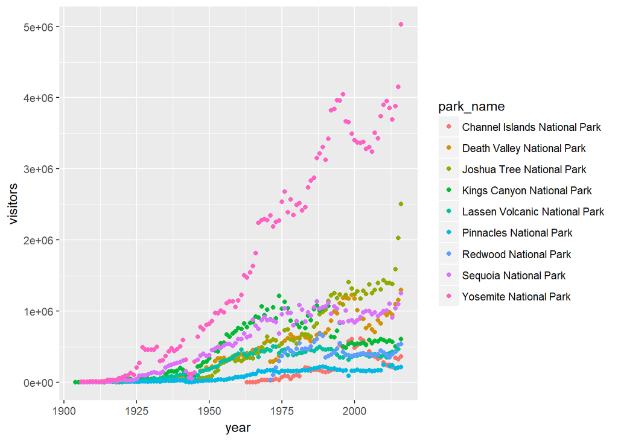

```r
ggplot(data = np_ca, aes(x = year, y = visitors)) +
  geom_point(aes(color = park_name))
```

## Customization - updating labels and titles

We customize graphs in ggplot *iteratively* by adding layers (using the plus sign ‘+’) to a base graphic and/or adding arguments within layers.

Use xlab() and ylab() layers to update x- and y-axis labels, and ggtitle() to add a graph title

graph + xlab(“This is my x-label”) + ylab(“This is my y-label”) + ggtitle(“This is my graph title”)

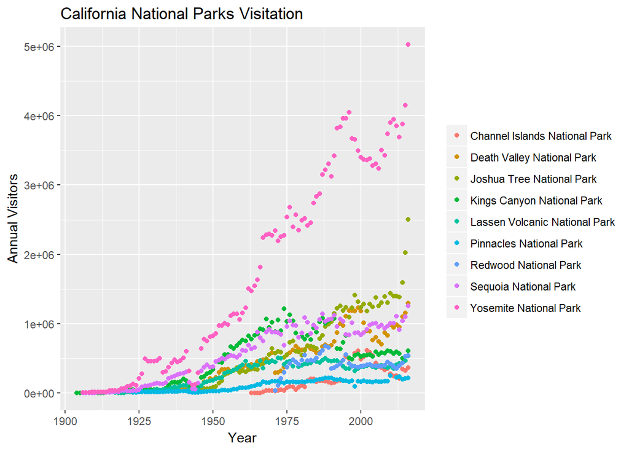

```r
ggplot(data = np_ca, aes(x = year, y = visitors)) +
  geom_point(aes(color = park_name)) +
  xlab("Year") +
  ylab("Annual Visitors") +
  ggtitle("California National Parks Visitation") +
  theme(legend.title=element_blank())
```

## ggplot themes

One way to make major changes to the overall aesthetic of your graph is using *themes* (that may exist in ggplot, or in other packages that you can load and install like ‘ggthemes’)

Some examples to try:

- theme_bw()
- theme_minimal()
- theme_classic()

Using themes doesn’t finalize your graph, but it can give you a better “starting point” for customization.

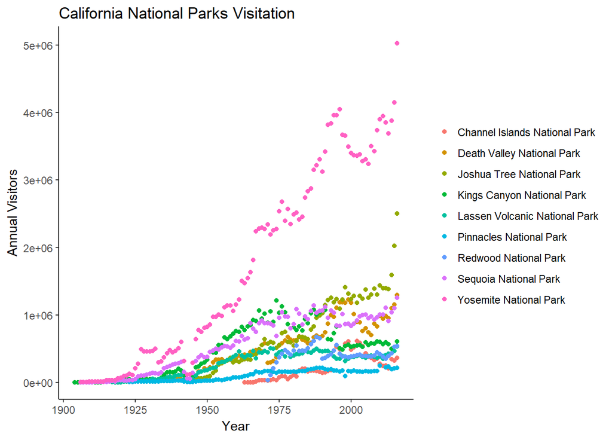

```r
ggplot(data = np_ca, aes(x = year, y = visitors)) +
  geom_point(aes(color = park_name)) +
  xlab("Year") +
  ylab("Annual Visitors") +
  theme_classic() +
  ggtitle("California National Parks Visitation") +
  theme(legend.title=element_blank())
```

## ggplot geoms (types of graphics)

We just made a few scatterplot graphs. But what if we wanted to make a line graph? Then do we have to start over? No…as long as the *type* of data is compatible with the new geom that you choose, then all you’d have to change is that layer.

Notice all of the types of geoms that exist when you start typing it in. And there are even other packages with **more** geom types that you can get.

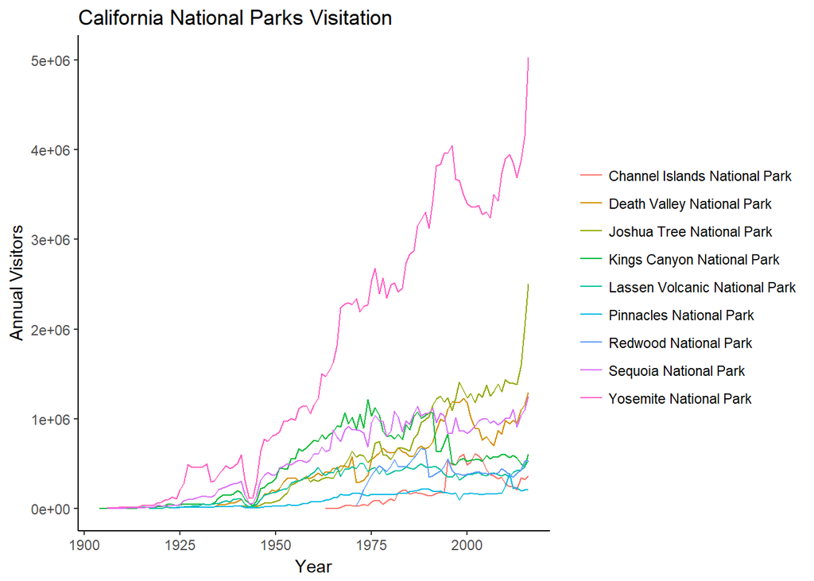

```r
ggplot(data = np_ca, aes(x = year, y = visitors)) +
  geom_line(aes(color = park_name)) +
  xlab("Year") +
  ylab("Annual Visitors") +
  theme_classic() +
  ggtitle("California National Parks Visitation") +
  theme(legend.title=element_blank())
```

Keep in mind that the type of graph you’re trying to create needs to be compatible with the data you’re telling it to use.

For example, if I want to make a histogram of visitation, then I couldn’t give it both an x- and y- quantitative variable (since the y-axis on a histogram is always just the frequency of events within a bin). So a histogram only asks for one variable. A boxplot typically has one categorical variable and one quantitative variable. For example:

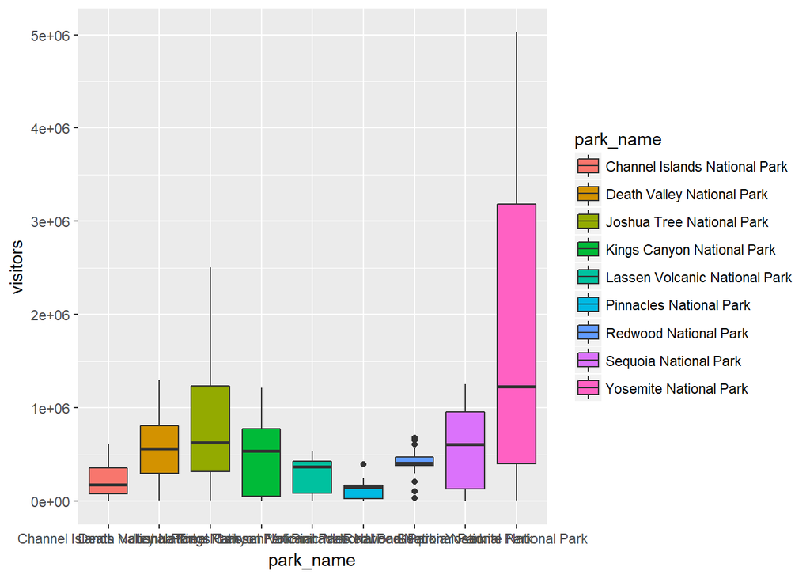

```r
ggplot(data = np_ca, aes(x = park_name, y = visitors)) +
  geom_boxplot(aes(fill = park_name)) # And you'd obviously want to customize (e.g. x-axis labels)
```

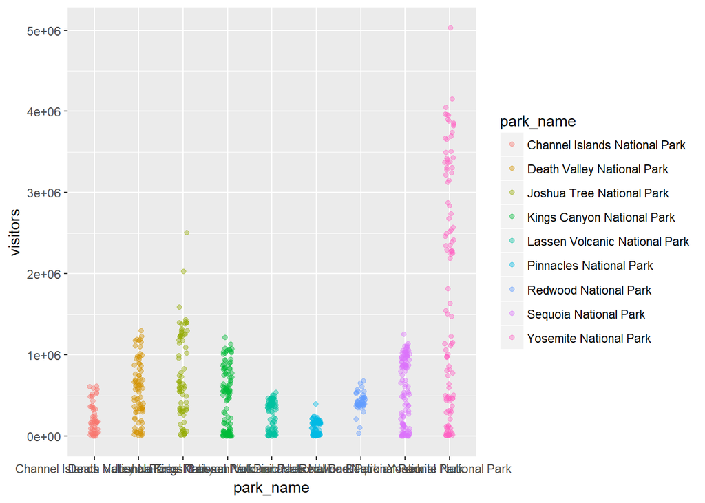

```r
ggplot(data = np_ca, aes(x = park_name, y = visitors)) +
  geom_jitter(aes(color = park_name), width = 0.1, alpha = 0.4)
```

…and then you can continue to customize.

Example customization:

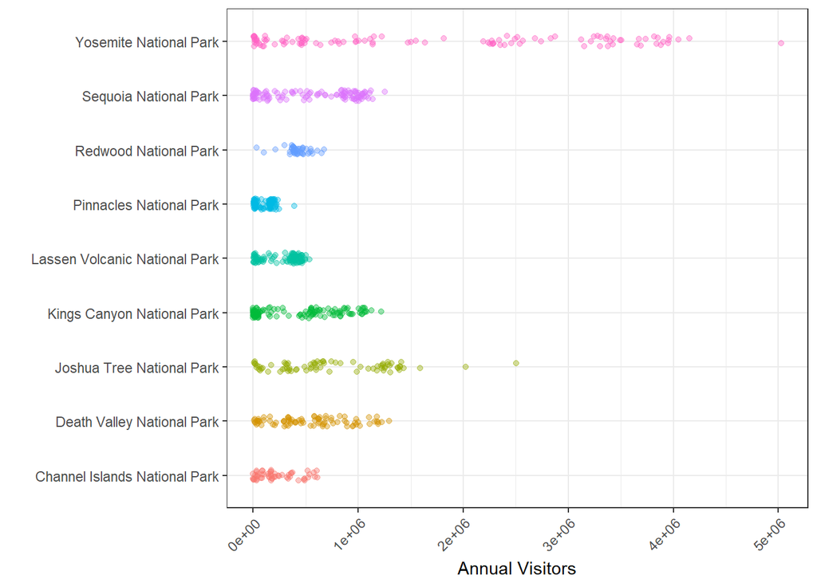

```r
ggplot(data = np_ca, aes(x = park_name, y = visitors)) +
  geom_jitter(aes(color = park_name),
              width = 0.1,
              alpha = 0.4) +
  theme_bw() +
  ylab("Annual Visitors") +
  xlab("") +
  coord_flip() +
  theme(legend.position = "none",
        axis.text.x = element_text(angle = 45, hjust = 1))
```

You can also *combine* different types of compatible graphs. For example, you can create a graph with lines and points by using both geom_line and geom_point.

Using the Dinosaur National Monument subset we created (dino_nm):

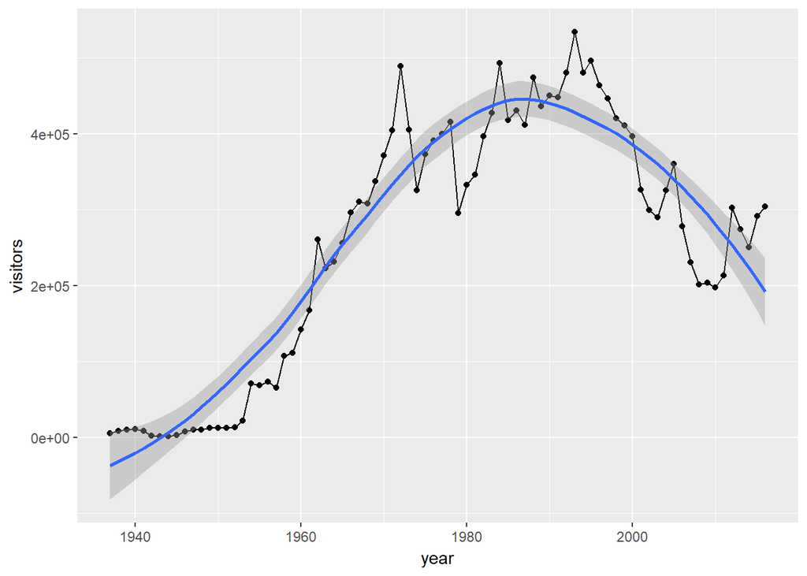

```r
ggplot(data = dino_nm, aes(x = year, y = visitors)) +
  geom_point() +
  geom_line() +
  geom_smooth()
```

## faceting

Considering our CA National Parks Visitation, what if we wanted each National Park to exist in its own graphics space? Would we need to create a new graph for each? No - we can use facet_wrap to split up the graph by a variable that we pick (here, park_name).

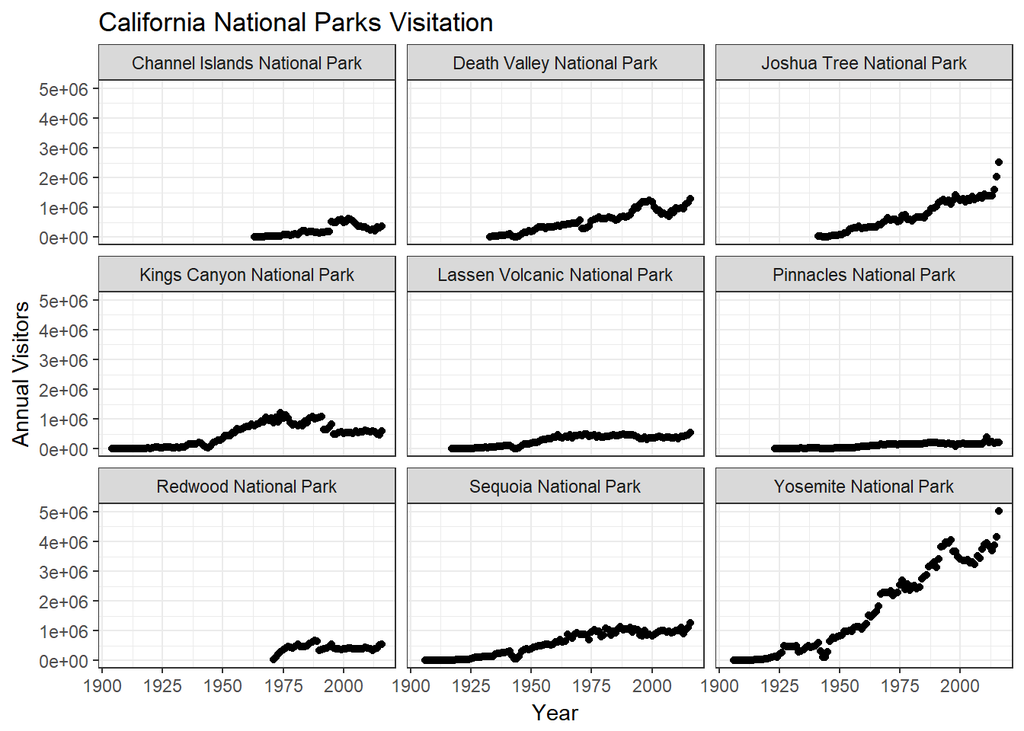

```r
ggplot(data = np_ca, aes(x = year, y = visitors)) +
  geom_point() +
  xlab("Year") +
  ylab("Annual Visitors") +
  theme_bw() +
  ggtitle("California National Parks Visitation") +
  facet_wrap(~park_name)
```

## Bar plots

First, let’s make a subset only of data for visitor counts from 2016 for all of the National Parks and National Monuments in the original np_visit dataset. I’ll call my subset ‘visit_16’.

```r
visit_16 <- np_visit %>%
  filter(year == 2016) %>%
  filter(type == "National Park" |
           type == "National Monument")
```

So we have 134 parks that are designated as either National Parks or National Monuments.

We can use geom_bar() in ggplot to *count* and display (as a bar) the number of times a certain outcome or character string appears in a column.

Here, we’ll create a bar graph showing how many NPs and NMs had recorded visitors in 2016. Note that you do NOT give it the counts - that’s what geom_bar does for us.

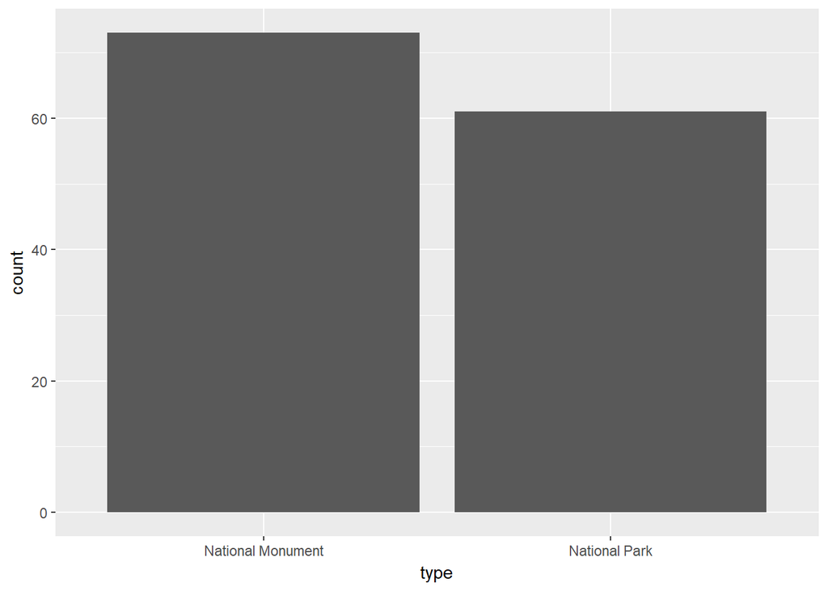

```r
ggplot(visit_16, aes(x = type)) +
  geom_bar()
```

What if we would like to know where (in what region) each of these exist? We can use the fill() argument to create a stacked bar graph, where the different colors indicate counts within each region.

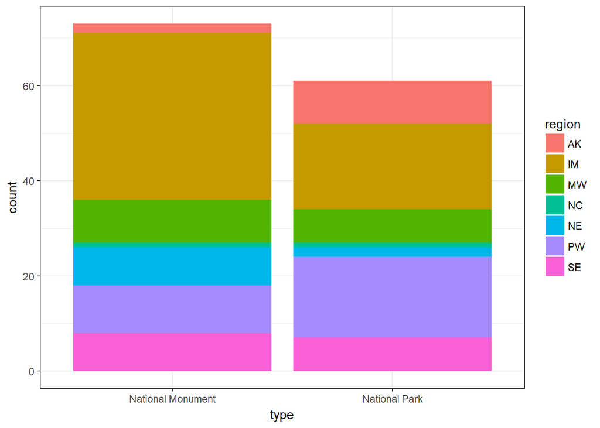

```r
ggplot(visit_16, aes(x = type)) +
  geom_bar(aes(fill = region)) +
  theme_bw()
```

Just a couple more things. The graph we just made shows the actual counts as a stacked bar graph. We might just be interested in the *proportions* of each monument type that exist in each region, or we might like an “unstacked” version.

Use the position argument to adjust geom_bar appearance. Set to “fill” if you want proportions shown (so all bars will be from 0 to 1), and “dodge” to have bars appear side-by-side for each group.

*Note that updating the position doesn’t automatically correct the y-axis label, as you’ll see below.*

Using position = “fill”:

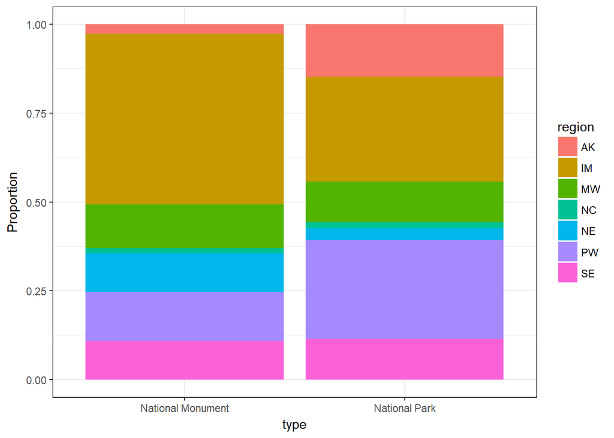

```r
ggplot(visit_16, aes(x = type)) +
  geom_bar(aes(fill = region), position = "fill") +
  theme_bw() +
  ylab("Proportion")
```

Using position = “dodge”:

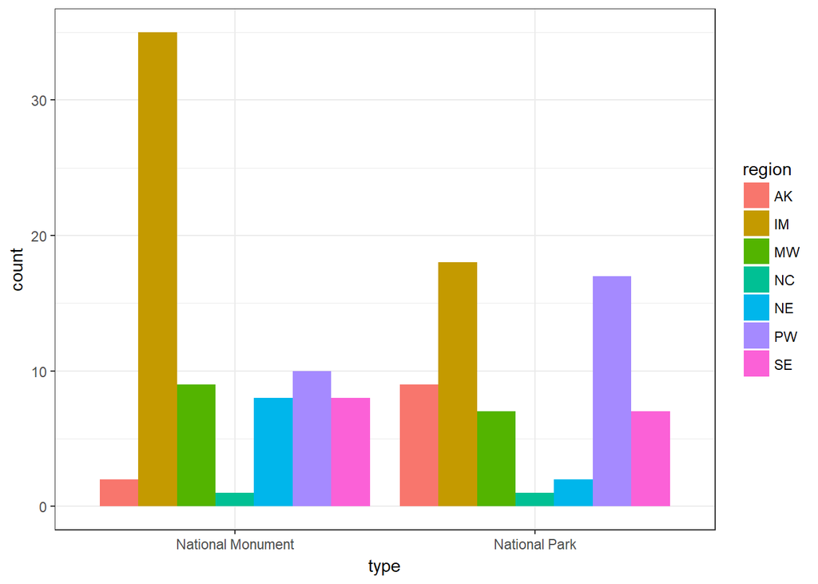

```r
ggplot(visit_16, aes(x = type)) +
  geom_bar(aes(fill = region), position = "dodge") +
  theme_bw()
```

## Exporting your gg-graphs

To export a hi-res version of your beautiful graph, make sure that you store your graph (assign it a name…we haven’t been doing that so far).

I’ll copy and paste the code for the bar graph I made above, and store it as ‘park_graph’.

```r
park_graph <- ggplot(visit_16, aes(x = type)) +
  geom_bar(aes(fill = region), position = "dodge") +
  theme_bw()
```

Then use ggsave() to export, including the size (width = , height = ) and resolution (dpi = ) as desired.

```r
ggsave("my_park_graph.png", park_graph, width = 5, height = 5, dpi = 300)
```